# How Does a Bike-Share Navigate Speedy Success?

Bryan Zhou

9/16/2021

## Scenario

Cyclistic, a bike sharing company launched in Chicago, 2016. The company has a fleet of 5,824 bicycles that are geotracked and locked into a network of 692 stations. Customers can unlocked and returned a bicycle to any station. The company offers customers several pricing plans: single-ride passes, full-day passes, and annual memberships. Lily Moreno, the marketing manager and the analyst team have determined that the future growth of the company will be converting the casual riders to annual members. The company will need a new marketing strategy to increase the number of annual membership.

## Ask

How do annual members and causal riders use Cyclistic bikes differently?

## Prepare

Data must satisfied these criteria: **ROCCC**

- **R**eliable
- **O**riginal
- **C**omprehensive
- **C**urrent
- **C**ite

The data consist of a series of divvy trips from the year 2013-2021 in zip file. The year 2020 is used for this analysis and the name of the files are change for readablility. The data are processed using R instead of Excel, because it is too large for Excel to handle. The data contain many NA. The data are obtained from this source: click here [link] (https://divvy-tripdata.s3.amazonaws.com/index.html)

The Motivate International Inc. (“Motivate”) has made their Divvy bicycle sharing service data public. click here for more info [link] (https://www.divvybikes.com/data-license-agreement)

## Process

Setup the working directory.

```
## [1] "C:/Divvy_Trips_2020/Code/09192021"
```

Load the necessary R packages.

```r
library(tidyverse)
library(lubridate)
```

Load the 12 months Divvy Trips 2020 csv files as a tibble, because these files are too large. The read_csv() import the data as a tibble and read.csv() import the data as a regular data frame.

### Wrangle And Merge Data

Look at the data frame structures and find common fields.

Inspect the datasets internal structures.

Determine if any of data frame have NA.

```r
divvyTrips_Q1_2020 <- mutate(divvyTrips_Q1_2020, "start_station_id"= as.character("start_station_id")
                  ,"end_station_id" = as.character("end_station_id"))

divvyTrips_April_2020 <- mutate(divvyTrips_April_2020, "start_station_id"= as.character("start_station_id")
                  ,"end_station_id" = as.character("end_station_id"))

divvyTrips_May_2020 <- mutate(divvyTrips_May_2020, "start_station_id"= as.character("start_station_id")
                  ,"end_station_id" = as.character("end_station_id"))

divvyTrips_June_2020 <- mutate(divvyTrips_June_2020, "start_station_id"= as.character("start_station_id")
                  ,"end_station_id" = as.character("end_station_id"))

divvyTrips_July_2020 <- mutate(divvyTrips_July_2020 , "start_station_id"= as.character("start_station_id")
                  ,"end_station_id" = as.character("end_station_id"))

divvyTrips_Aug_2020 <- mutate(divvyTrips_Aug_2020, "start_station_id"= as.character("start_station_id")
                  ,"end_station_id" = as.character("end_station_id"))

divvyTrips_Sept_2020 <- mutate(divvyTrips_Sept_2020, "start_station_id"= as.character("start_station_id")
                  ,"end_station_id" = as.character("end_station_id"))

divvyTrips_Oct_2020 <- mutate(divvyTrips_Oct_2020 , "start_station_id"= as.character("start_station_id")
                  ,"end_station_id" = as.character("end_station_id"))

divvyTrips_Nov_2020 <- mutate(divvyTrips_Nov_2020, "start_station_id"= as.character("start_station_id")
                  ,"end_station_id" = as.character("end_station_id"))
```

### Merge

Merge all the data into one data frame.

```r
all_trips <- bind_rows(divvyTrips_Q1_2020, divvyTrips_April_2020, divvyTrips_May_2020, divvyTrips_June_2020, divvyTrips_July_2020, divvyTrips_Aug_2020, divvyTrips_Sept_2020, divvyTrips_Oct_2020, divvyTrips_Nov_2020, divvyTrips_Dec_2020)
```

When inspecting the data frame with View() function, the Merge process resulted in a data frame with incorrect values. The start_station_id and end_station_id columns have their NA values replaced with their respective column names. This will only cause confusion in the later analysis. Applied the mutate() function to change those values back to NA.

```r
all_trips <- all_trips %>% mutate(start_station_id = replace(start_station_id, start_station_id =="start_station_id", NA))
```

```r
 all_trips <- all_trips %>% mutate(end_station_id = replace(end_station_id, end_station_id =="end_station_id", NA))
```

```r
dim(all_trips)
```

```
## [1] 3541683      13
```

### More Data Wrangling

Fill in the missing values for start station id, start station name, end station id and end station name with their respective values using the fill() function. Arrange the selected columns and then filter out any columns that can not be used to match the values. The ‘fill’ is used to complete the missing values.

```r
all_trips_v2 <-all_trips %>% arrange(start_station_name, start_station_id, end_station_name, end_station_id, .by_group = TRUE)
```

```r
all_trips_v2 <- all_trips_v2 %>% filter(!is.na(all_trips_v2$start_station_name), !is.na(all_trips_v2$end_station_name))
```

```r
all_trips_v2 <- all_trips_v2 %>% fill(start_station_id,  .direction = "downup")
```

```r
all_trips_v2 <- all_trips_v2 %>%  arrange(end_station_name, end_station_id, .by_group = TRUE) %>%  fill(end_station_id,  .direction = "downup")
```

Remove the latitude and longitude fields from the data frame.

```r
all_trips_v3 <- all_trips_v2 %>% select(-c(start_lat, start_lng, end_lat, end_lng))
```

Inspect columns of the new data frame

```r
colnames(all_trips_v3)
```

```
## [1] "ride_id"            "rideable_type"      "started_at"
## [4] "ended_at"           "start_station_name" "start_station_id"
## [7] "end_station_name"   "end_station_id"     "member_casual"
```

Inspect the number of rows in the new data frame.

```r
nrow(all_trips_v3)
```

```
## [1] 3390253
```

Inspect the dimension of the new data frame.

```r
dim(all_trips_v3)
```

```
## [1] 3390253       9
```

Inspect the structure of the new data frame.

```r
str(all_trips_v3)
```

```
## tibble [3,390,253 x 9] (S3: tbl_df/tbl/data.frame)
##  $ ride_id           : chr [1:3390253] "78BD05B222A725DD" "3C9E3740A6EF9658" "30D742AEB8E7F232" "507E4F9814729527" ...
##  $ rideable_type     : chr [1:3390253] "classic_bike" "docked_bike" "electric_bike" "electric_bike" ...
##  $ started_at        : POSIXct[1:3390253], format: "2020-12-24 17:57:45" "2020-12-27 14:39:11" ...
##  $ ended_at          : POSIXct[1:3390253], format: "2020-12-24 17:57:54" "2020-12-27 14:41:44" ...
##  $ start_station_name: chr [1:3390253] "2112 W Peterson Ave" "2112 W Peterson Ave" "2112 W Peterson Ave" "2112 W Peterson Ave" ...
##  $ start_station_id  : chr [1:3390253] "KA1504000155" "KA1504000155" "KA1504000155" "KA1504000155" ...
##  $ end_station_name  : chr [1:3390253] "2112 W Peterson Ave" "2112 W Peterson Ave" "2112 W Peterson Ave" "2112 W Peterson Ave" ...
##  $ end_station_id    : chr [1:3390253] "KA1504000155" "KA1504000155" "KA1504000155" "KA1504000155" ...
##  $ member_casual     : chr [1:3390253] "member" "casual" "casual" "member" ...
```

```r
summary(all_trips_v3)
```

```
##    ride_id          rideable_type        started_at
##  Length:3390253     Length:3390253     Min.   :2020-01-01 00:04:44
##  Class :character   Class :character   1st Qu.:2020-06-15 18:53:10
##  Mode  :character   Mode  :character   Median :2020-08-06 11:45:18
##                                        Mean   :2020-07-25 08:11:40
##                                        3rd Qu.:2020-09-20 17:26:26
##                                        Max.   :2020-12-31 23:59:59
##     ended_at                   start_station_name start_station_id
##  Min.   :2020-01-01 00:10:54   Length:3390253     Length:3390253
##  1st Qu.:2020-06-15 19:22:29   Class :character   Class :character
##  Median :2020-08-06 12:11:17   Mode  :character   Mode  :character
##  Mean   :2020-07-25 08:36:58
##  3rd Qu.:2020-09-20 17:55:42
##  Max.   :2021-01-03 08:54:11
##  end_station_name   end_station_id     member_casual
##  Length:3390253     Length:3390253     Length:3390253
##  Class :character   Class :character   Class :character
##  Mode  :character   Mode  :character   Mode  :character
##
##
##
```

Check member_casual column. There should be only two categories: member and casual. Level" is a special property of a column that is retained even if a subset does not contain any values from a specific level.

```r
 table(all_trips_v3$member_casual)
```

```
##
##  casual  member
## 1301241 2089012
```

Add more fields: day, month, year for more data aggregation and analysis. The default format is yyyy-mm-dd for the date. Add a ride_length field to calculate all trips in seconds.

```r
 all_trips_v3$date <-as.Date(all_trips_v3$started_at)
 all_trips_v3$month <-format(as.Date(all_trips_v3$date), "%m")
 all_trips_v3$day <-format(as.Date(all_trips_v3$date), "%d")
 all_trips_v3$year <-format(as.Date(all_trips_v3$date), "%Y")
 all_trips_v3$day_of_week <-format(as.Date(all_trips_v3$date), "%A")
 all_trips_v3$ride_length <- difftime(all_trips_v3$ended_at ,all_trips_v3$started_at)
```

Inspect the new data frame structure.

```r
str(all_trips_v3)
```

```
## tibble [3,390,253 x 15] (S3: tbl_df/tbl/data.frame)
##  $ ride_id           : chr [1:3390253] "78BD05B222A725DD" "3C9E3740A6EF9658" "30D742AEB8E7F232" "507E4F9814729527" ...
##  $ rideable_type     : chr [1:3390253] "classic_bike" "docked_bike" "electric_bike" "electric_bike" ...
##  $ started_at        : POSIXct[1:3390253], format: "2020-12-24 17:57:45" "2020-12-27 14:39:11" ...
##  $ ended_at          : POSIXct[1:3390253], format: "2020-12-24 17:57:54" "2020-12-27 14:41:44" ...
##  $ start_station_name: chr [1:3390253] "2112 W Peterson Ave" "2112 W Peterson Ave" "2112 W Peterson Ave" "2112 W Peterson Ave" ...
##  $ start_station_id  : chr [1:3390253] "KA1504000155" "KA1504000155" "KA1504000155" "KA1504000155" ...
##  $ end_station_name  : chr [1:3390253] "2112 W Peterson Ave" "2112 W Peterson Ave" "2112 W Peterson Ave" "2112 W Peterson Ave" ...
##  $ end_station_id    : chr [1:3390253] "KA1504000155" "KA1504000155" "KA1504000155" "KA1504000155" ...
##  $ member_casual     : chr [1:3390253] "member" "casual" "casual" "member" ...
##  $ date              : Date[1:3390253], format: "2020-12-24" "2020-12-27" ...
##  $ month             : chr [1:3390253] "12" "12" "12" "12" ...
##  $ day               : chr [1:3390253] "24" "27" "20" "22" ...
##  $ year              : chr [1:3390253] "2020" "2020" "2020" "2020" ...
##  $ day_of_week       : chr [1:3390253] "Thursday" "Sunday" "Sunday" "Tuesday" ...
##  $ ride_length       : 'difftime' num [1:3390253] 9 153 2835 800 ...
##   ..- attr(*, "units")= chr "secs"
```

```r
 is.factor(all_trips_v3$ride_length)
```

```
## [1] FALSE
```

```r
 all_trips_v3$ride_length <-as.numeric(as.character(all_trips_v3$ride_length))
 is.numeric(all_trips_v3$ride_length)
```

```
## [1] TRUE
```

Remove negative values and create a new data frame.

```r
 all_trips_v4 <- all_trips_v3[!(all_trips_v3$start_station_name == "HQ QR" | all_trips_v3$ride_length < 0),]
```

## Analyze

The statistical summary of the new data frame.

```r
summary(all_trips_v4)
```

```
##    ride_id          rideable_type        started_at
##  Length:3376035     Length:3376035     Min.   :2020-01-01 00:04:44
##  Class :character   Class :character   1st Qu.:2020-06-15 19:27:47
##  Mode  :character   Mode  :character   Median :2020-08-06 10:55:32
##                                        Mean   :2020-07-25 08:48:55
##                                        3rd Qu.:2020-09-20 17:13:25
##                                        Max.   :2020-12-31 23:59:59
##     ended_at                   start_station_name start_station_id
##  Min.   :2020-01-01 00:10:54   Length:3376035     Length:3376035
##  1st Qu.:2020-06-15 19:58:33   Class :character   Class :character
##  Median :2020-08-06 11:23:01   Mode  :character   Mode  :character
##  Mean   :2020-07-25 09:16:59
##  3rd Qu.:2020-09-20 17:42:03
##  Max.   :2021-01-03 08:54:11
##  end_station_name   end_station_id     member_casual           date
##  Length:3376035     Length:3376035     Length:3376035     Min.   :2020-01-01
##  Class :character   Class :character   Class :character   1st Qu.:2020-06-15
##  Mode  :character   Mode  :character   Mode  :character   Median :2020-08-06
##                                                           Mean   :2020-07-24
##                                                           3rd Qu.:2020-09-20
##                                                           Max.   :2020-12-31
##     month               day                year           day_of_week
##  Length:3376035     Length:3376035     Length:3376035     Length:3376035
##  Class :character   Class :character   Class :character   Class :character
##  Mode  :character   Mode  :character   Mode  :character   Mode  :character
##
##
##
##   ride_length
##  Min.   :      0
##  1st Qu.:    467
##  Median :    854
##  Mean   :   1684
##  3rd Qu.:   1568
##  Max.   :9387024
```

### Descriptive Analysis

The statistical summary of ride length.

```r
summary(all_trips_v4$ride_length)
```

```
##    Min. 1st Qu.  Median    Mean 3rd Qu.    Max.
##       0     467     854    1684    1568 9387024
```

Compare the casual and member rider.

```r
 aggregate(all_trips_v4$ride_length ~ all_trips_v4$member_casual, FUN = mean)
```

```
##   all_trips_v4$member_casual all_trips_v4$ride_length
## 1                     casual                 2884.378
## 2                     member                  937.833
```

```r
 aggregate(all_trips_v4$ride_length ~ all_trips_v4$member_casual, FUN = median)
```

```
##   all_trips_v4$member_casual all_trips_v4$ride_length
## 1                     casual                     1319
## 2                     member                      668
```

```r
 aggregate(all_trips_v4$ride_length ~ all_trips_v4$member_casual, FUN = max)
```

```
##   all_trips_v4$member_casual all_trips_v4$ride_length
## 1                     casual                  9387024
## 2                     member                  5627611
```

```r
 aggregate(all_trips_v4$ride_length ~ all_trips_v4$member_casual, FUN = min)
```

```
##   all_trips_v4$member_casual all_trips_v4$ride_length
## 1                     casual                        0
## 2                     member                        0
```

Casual rider have longest ride duration. Find the average ride time by each day for member and casual user.

```r
 aggregate(all_trips_v4$ride_length ~ all_trips_v4$member_casual + all_trips_v4$day_of_week, FUN = mean)
```

```
##    all_trips_v4$member_casual all_trips_v4$day_of_week all_trips_v4$ride_length
## 1                      casual                   Friday                2759.6401
## 2                      member                   Friday                 922.3003
## 3                      casual                   Monday                2838.3635
## 4                      member                   Monday                 891.3397
## 5                      casual                 Saturday                2938.9982
## 6                      member                 Saturday                1068.2705
## 7                      casual                   Sunday                3283.4420
## 8                      member                   Sunday                1088.3499
## 9                      casual                 Thursday                2834.1089
## 10                     member                 Thursday                 878.7530
## 11                     casual                  Tuesday                2604.1124
## 12                     member                  Tuesday                 864.1515
## 13                     casual                Wednesday                2602.4863
## 14                     member                Wednesday                 877.6955
```

Fix the days of the week, because they are out of order.

```r
 all_trips_v4$day_of_week <- ordered(all_trips_v4$day_of_week, levels=c("Sunday", "Monday",
                                                                        "Tuesday", "Wednesday", "Thursday", "Friday", "Saturday"))
```

Repeat the average ride time by each day for member and causal user. Analyze ridership data by type and weekday; create weekday field using wday(); group by user type and weekday. Calculate the number of rides and average calculates; calculate the average duration and sort the result.

```r
aggregate(all_trips_v4$ride_length ~ all_trips_v4$member_casual + all_trips_v4$day_of_week, FUN = mean)
```

```
##    all_trips_v4$member_casual all_trips_v4$day_of_week all_trips_v4$ride_length
## 1                      casual                   Sunday                3283.4420
## 2                      member                   Sunday                1088.3499
## 3                      casual                   Monday                2838.3635
## 4                      member                   Monday                 891.3397
## 5                      casual                  Tuesday                2604.1124
## 6                      member                  Tuesday                 864.1515
## 7                      casual                Wednesday                2602.4863
## 8                      member                Wednesday                 877.6955
## 9                      casual                 Thursday                2834.1089
## 10                     member                 Thursday                 878.7530
## 11                     casual                   Friday                2759.6401
## 12                     member                   Friday                 922.3003
## 13                     casual                 Saturday                2938.9982
## 14                     member                 Saturday                1068.2705
```

```r
aggregate(all_trips_v4$ride_length ~ all_trips_v4$member_casual + all_trips_v4$day_of_week, FUN = mean)
```

```
##    all_trips_v4$member_casual all_trips_v4$day_of_week all_trips_v4$ride_length
## 1                      casual                   Sunday                3283.4420
## 2                      member                   Sunday                1088.3499
## 3                      casual                   Monday                2838.3635
## 4                      member                   Monday                 891.3397
## 5                      casual                  Tuesday                2604.1124
## 6                      member                  Tuesday                 864.1515
## 7                      casual                Wednesday                2602.4863
## 8                      member                Wednesday                 877.6955
## 9                      casual                 Thursday                2834.1089
## 10                     member                 Thursday                 878.7530
## 11                     casual                   Friday                2759.6401
## 12                     member                   Friday                 922.3003
## 13                     casual                 Saturday                2938.9982
## 14                     member                 Saturday                1068.2705
```

```r
all_trips_v4 %>% mutate(weekday = wday(started_at, label = TRUE)) %>% group_by(member_casual,weekday) %>% summarise(number_of_rides = n(),average_duration = mean(ride_length)) %>%
         arrange(member_casual, weekday)
```

```
## # A tibble: 14 x 4
## # Groups:   member_casual [2]
##    member_casual weekday number_of_rides average_duration
##    <chr>         <ord>             <int>            <dbl>
##  1 casual        Sun              245216            3283.
##  2 casual        Mon              132883            2838.
##  3 casual        Tue              129225            2604.
##  4 casual        Wed              143320            2602.
##  5 casual        Thu              152932            2834.
##  6 casual        Fri              190890            2760.
##  7 casual        Sat              299790            2939.
##  8 member        Sun              258770            1088.
##  9 member        Mon              280010             891.
## 10 member        Tue              302485             864.
## 11 member        Wed              316271             878.
## 12 member        Thu              314833             879.
## 13 member        Fri              311796             922.
## 14 member        Sat              297614            1068.
```

## Share

Visualize the number of rides by rider type.

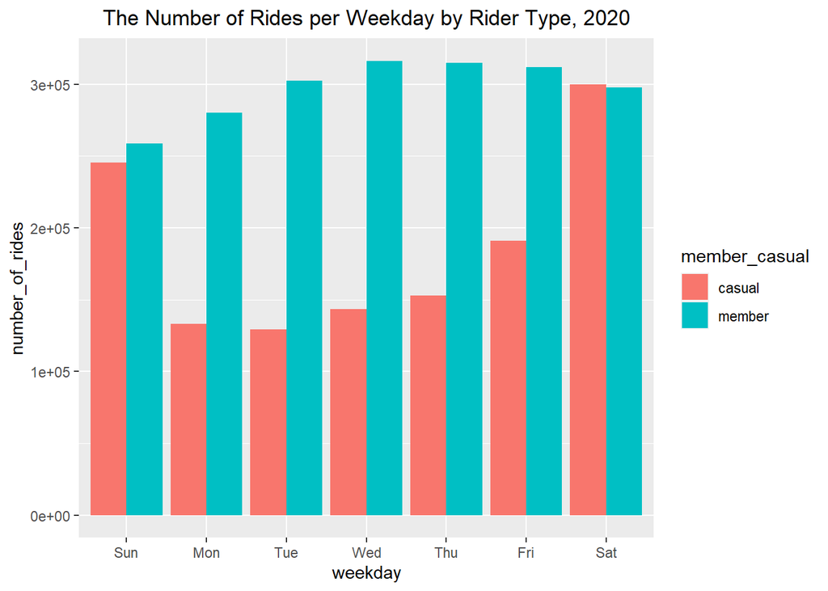

```r
 all_trips_v4 %>% mutate(weekday = wday(started_at, label = TRUE)) %>% group_by(member_casual, weekday) %>%
         summarise(number_of_rides = n()
         ,average_duration = mean(ride_length)) %>%
         arrange(member_casual, weekday) %>%
         ggplot(aes(x = weekday, y = number_of_rides, fill = member_casual)) +
         geom_col(position = "dodge") + ggtitle("The Number of Rides per Weekday by Rider Type, 2020") + theme(plot.title = element_text(hjust = 0.5))
```

The average duration of all trips.

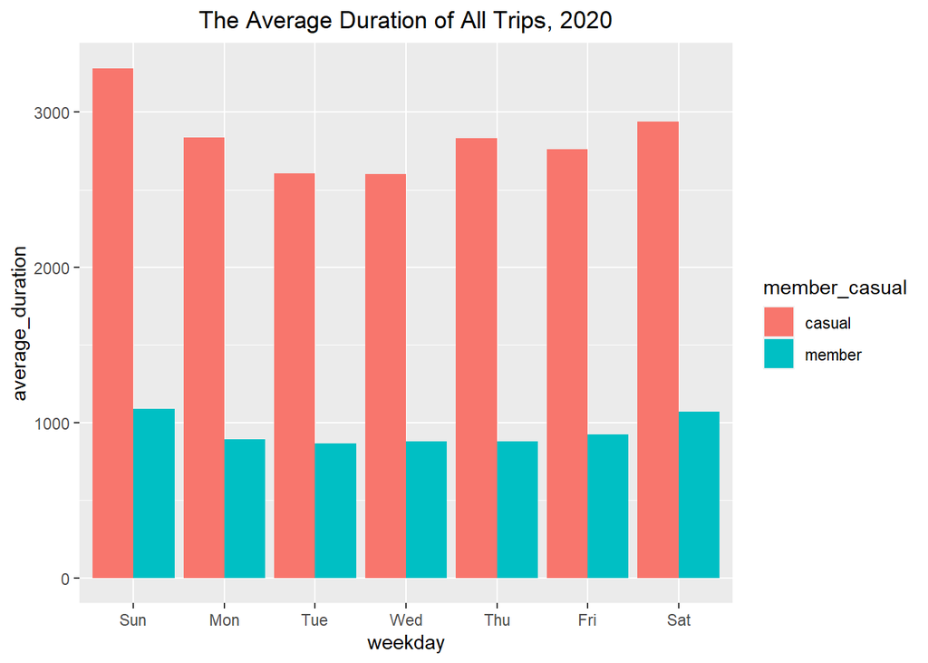

```r
all_trips_v4 %>%
         mutate(weekday = wday(started_at, label = TRUE)) %>%
         group_by(member_casual, weekday) %>%
         summarise(number_of_rides = n()
                   ,average_duration = mean(ride_length)) %>%
         arrange(member_casual, weekday) %>%
         ggplot(aes(x = weekday, y = average_duration, fill = member_casual)) +
         geom_col(position = "dodge") + ggtitle("The Average Duration of All Trips, 2020") + theme(plot.title = element_text(hjust = 0.5))
```

Bike preference among rider type.

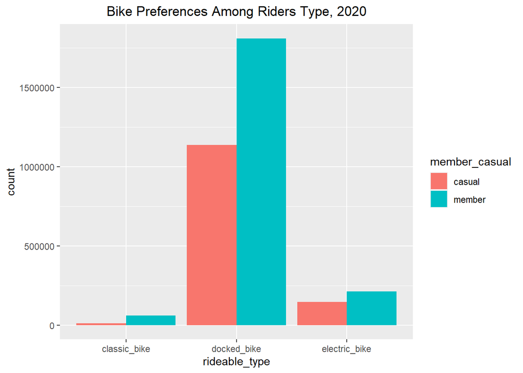

```r
ggplot(data=all_trips_v4) +geom_bar(mapping = aes(x=rideable_type, fill = member_casual), position = "dodge") + ggtitle("Bike Preferences Among Riders Type, 2020") + theme(plot.title = element_text(hjust = 0.5))
```

The number of rider by rider_type per month.

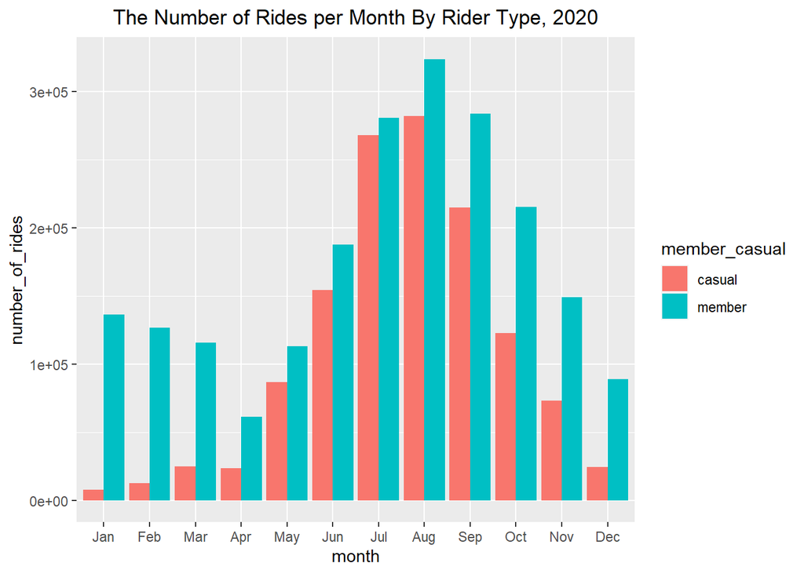

```r
all_trips_v4 %>% mutate(month = month(started_at, label = TRUE)) %>% group_by(member_casual, month) %>%
  summarise(number_of_rides = n()
            ,average_duration = mean(ride_length)) %>%
  arrange(member_casual, month) %>%
  ggplot(aes(x = month, y = number_of_rides, fill = member_casual)) +
  geom_col(position = "dodge") +ggtitle("The Number of Rides per Month By Rider Type, 2020") + theme(plot.title = element_text(hjust = 0.5))
```

Visualize the average duration of all trips per month.

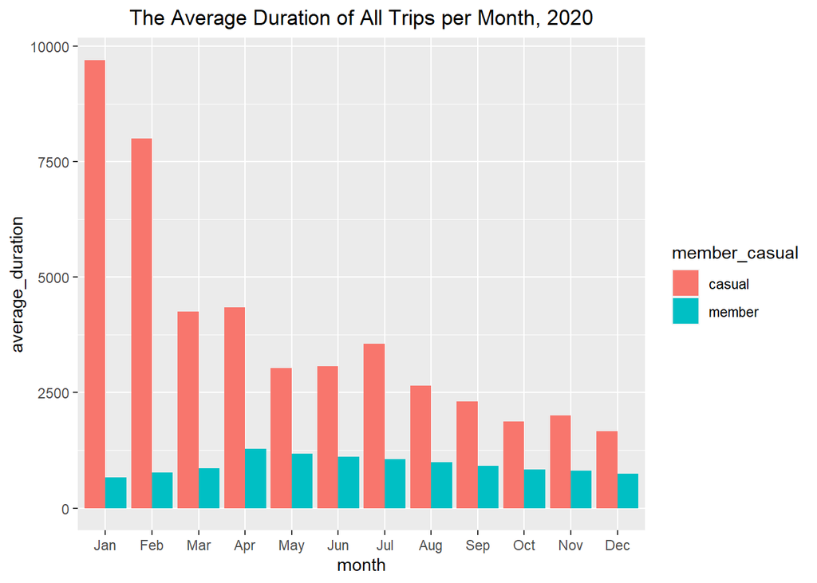

```r
 all_trips_v4 %>%
         mutate(month = month(started_at, label = TRUE)) %>%
         group_by(member_casual, month) %>%
         summarise(number_of_rides = n()
                   ,average_duration = mean(ride_length)) %>%
         arrange(member_casual, month) %>%
         ggplot(aes(x = month, y = average_duration, fill = member_casual)) +
         geom_col(position = "dodge") +ggtitle ("The Average Duration of All Trips per Month, 2020") + theme(plot.title = element_text(hjust = 0.5))
```

Create csv files for future analysis.

```r
 counts <- aggregate(all_trips_v4$ride_length ~ all_trips_v4$member_casual +
                             all_trips_v4$day_of_week, FUN = mean)
 write.csv(counts,file ="C:/Divvy_Trips_2020/avg_ride_length.csv")
 write.csv(all_trips_v4, file ="C:/Divvy_Trips_2020/all_trips_2020.csv", row.names = FALSE)
```

## Act

### Conclusion

Casual riders have the longest ride duration overall especially in the months of January and February. Casual riders are most active during the weekends and during the summers. Both member and casual rider have strong preference for docked bike.

### Recommendation

```
 * Ask riders to take a survey and hand out discounts.
 * Use marketing ads to target casual riders during the weekends and summers.
 * Create a promotional video and host it on social media or other affiliate sites.
```